# SDC Data Visualization Guidelines

Working document

Author

Cedric Vidonne

Published

August 18, 2026

## Colours

The palettes below are for **encoding data only** — bars, lines, pie slices, map areas. Colours for chart *elements* (axes, gridlines, labels) are handled separately, later.

Every palette is shown at **7 colours** so the full set is visible. In practice a categorical palette stays readable up to about **5–6 categories**; beyond that, colours become hard to tell apart, including for colour-blind readers.

### Current palette

The categorical palette from the EDA strategy — our starting point and baseline for comparison.

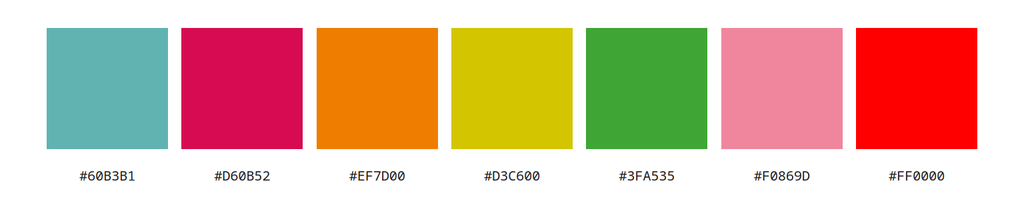

### OKLCH

Built on a perceptual lightness staircase in OKLCH: same teal and pinkred anchors, with the light-pink and pure red swapped for a blue and a violet.

**Pro:** even lightness, more colour-blind-robust, works in black & white.

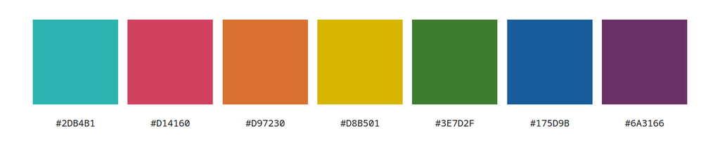

### Bright one

The same hues pushed higher in chroma for a livelier, near-neon feel.

**Pro:** punchy and high-energy, strong on screen.

**Con:** reads less institutional and can strain the eye in large filled areas.

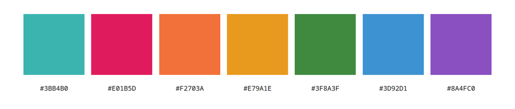

### GPT one

A muted, earthy take: desaturated naturals (brown, gold, olive) alongside the teal and pinkred anchors.

**Pro:** soft, cohesive, easy on the eye for large filled areas.

**Con:** lower chroma makes some hues harder to tell apart at small sizes, and it feels less lively.

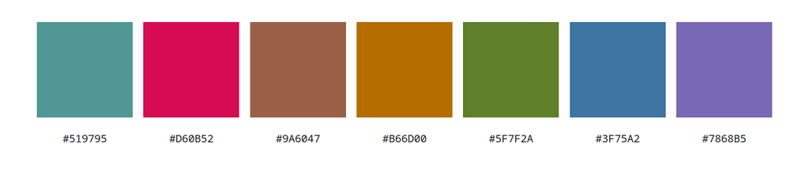

### Claude one

Similar earthy direction, but engineered so every colour clears a minimum contrast on white and the lightness steps stay ordered.

**Pro:** accessible and well-balanced, dependable across chart types.

**Con:** the darker, contrast-driven hues compress the range and can look a little sober.

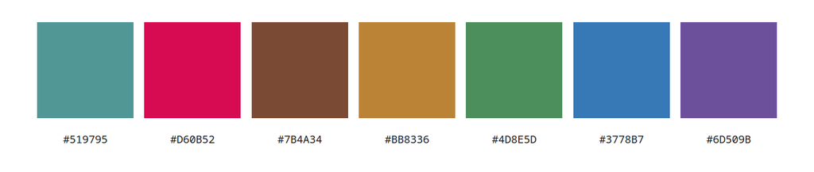

### Warm one

**Pro:** cohesive, warm identity.

**Con:** the warm cluster risks similar lightness, reducing how many colours truly stand apart.

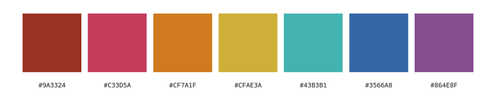

### Cool one

The mirror of warm — anchored in blues, greens and teal, with warm colours only as accents.

**Pro:** calm and institutional.

**Con:** the cool cluster can look samey and less energetic.

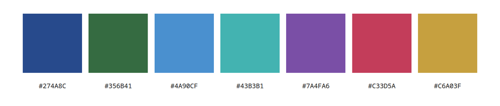